# Data Cleaning

```python
import numpy as np
import pandas as pd
```

```python
df=pd.read_csv(r"C:\Users\mekal\Web Scraping\cars24 dataset.csv")
```

```python
df
```

|  | Manufacture_year | Brand | Model | Km_Driven | Registration | Transmission_type | Fuel | Price |
| --- | --- | --- | --- | --- | --- | --- | --- | --- |
| 0 | 2012 | Maruti | Maruti Wagon R 1.0 | 99.90k | AP-10 | Manual | Petrol | 2.04 lakh |
| 1 | 2014 | Maruti | Maruti Alto 800 LXI | 29.29k | AP-09 | Manual | Petrol | 1.99 lakh |
| 2 | 2016 | Honda | Honda BR-V 1.5L I-VTEC | 56.18k | TS-09 | Auto | Petrol | 5.02 lakh |
| 3 | 2013 | Renault | Renault Scala RXE DIESEL | NaN | AP-10 | Manual | Diesel | 1.89 lakh |
| 4 | 2016 | Maruti | Maruti Celerio ZXI AMT | 71.19k | TS-03 | Auto | Petrol | 3.68 lakh |
| ... | ... | ... | ... | ... | ... | ... | ... | ... |
| 395 | 2020 | Tata | Tata Tiago XZ PETROL | NaN | TS-35 | Manual | Petrol | 3.17 lakh |
| 396 | 2014 | Hyundai | Hyundai Grand i10 ASTA | 75.20k | TS-09 | Manual | Petrol | 3.45 lakh |
| 397 | 2020 | Toyota | Toyota URBAN CRUISER 1.5L | NaN | TS-08 | Auto | Petrol | 8.08 lakh |
| 398 | 2018 | Maruti | Maruti Swift VXI AMT | 47.51k | TS-09 | Auto | Petrol | 4.45 lakh |
| 399 | 2020 | Maruti | Maruti New Wagon-R VXI | 55.85k | TS-07 | Manual | Petrol | 3.56 lakh |

400 rows × 8 columns

```python
df.info()
```

```
<class 'pandas.core.frame.DataFrame'>
RangeIndex: 400 entries, 0 to 399
Data columns (total 8 columns):
 #   Column             Non-Null Count  Dtype
---  ------             --------------  -----
 0   Manufacture_year   400 non-null    int64
 1   Brand              400 non-null    object
 2   Model              400 non-null    object
 3   Km_Driven          300 non-null    object
 4   Registration       400 non-null    object
 5   Transmission_type  400 non-null    object
 6   Fuel               400 non-null    object
 7   Price              400 non-null    object
dtypes: int64(1), object(7)
memory usage: 25.1+ KB
```

```python
df["Price"]=(df["Price"].str.replace(".","").str.replace(" ","").str.replace("lakh","000").astype(int))
```

```python
df
```

|  | Manufacture_year | Brand | Model | Km_Driven | Registration | Transmission_type | Fuel | Price |
| --- | --- | --- | --- | --- | --- | --- | --- | --- |
| 0 | 2012 | Maruti | Maruti Wagon R 1.0 | 99.90k | AP-10 | Manual | Petrol | 204000 |
| 1 | 2014 | Maruti | Maruti Alto 800 LXI | 29.29k | AP-09 | Manual | Petrol | 199000 |
| 2 | 2016 | Honda | Honda BR-V 1.5L I-VTEC | 56.18k | TS-09 | Auto | Petrol | 502000 |
| 3 | 2013 | Renault | Renault Scala RXE DIESEL | NaN | AP-10 | Manual | Diesel | 189000 |
| 4 | 2016 | Maruti | Maruti Celerio ZXI AMT | 71.19k | TS-03 | Auto | Petrol | 368000 |
| ... | ... | ... | ... | ... | ... | ... | ... | ... |
| 395 | 2020 | Tata | Tata Tiago XZ PETROL | NaN | TS-35 | Manual | Petrol | 317000 |
| 396 | 2014 | Hyundai | Hyundai Grand i10 ASTA | 75.20k | TS-09 | Manual | Petrol | 345000 |
| 397 | 2020 | Toyota | Toyota URBAN CRUISER 1.5L | NaN | TS-08 | Auto | Petrol | 808000 |
| 398 | 2018 | Maruti | Maruti Swift VXI AMT | 47.51k | TS-09 | Auto | Petrol | 445000 |
| 399 | 2020 | Maruti | Maruti New Wagon-R VXI | 55.85k | TS-07 | Manual | Petrol | 356000 |

400 rows × 8 columns

```python
df["Km_Driven"]=(df["Km_Driven"].str.replace(".","").str.replace("k","0").astype(float))
```

```python
df
```

|  | Manufacture_year | Brand | Model | Km_Driven | Registration | Transmission_type | Fuel | Price |
| --- | --- | --- | --- | --- | --- | --- | --- | --- |
| 0 | 2012 | Maruti | Maruti Wagon R 1.0 | 99900.0 | AP-10 | Manual | Petrol | 204000 |
| 1 | 2014 | Maruti | Maruti Alto 800 LXI | 29290.0 | AP-09 | Manual | Petrol | 199000 |
| 2 | 2016 | Honda | Honda BR-V 1.5L I-VTEC | 56180.0 | TS-09 | Auto | Petrol | 502000 |
| 3 | 2013 | Renault | Renault Scala RXE DIESEL | NaN | AP-10 | Manual | Diesel | 189000 |
| 4 | 2016 | Maruti | Maruti Celerio ZXI AMT | 71190.0 | TS-03 | Auto | Petrol | 368000 |
| ... | ... | ... | ... | ... | ... | ... | ... | ... |
| 395 | 2020 | Tata | Tata Tiago XZ PETROL | NaN | TS-35 | Manual | Petrol | 317000 |
| 396 | 2014 | Hyundai | Hyundai Grand i10 ASTA | 75200.0 | TS-09 | Manual | Petrol | 345000 |
| 397 | 2020 | Toyota | Toyota URBAN CRUISER 1.5L | NaN | TS-08 | Auto | Petrol | 808000 |
| 398 | 2018 | Maruti | Maruti Swift VXI AMT | 47510.0 | TS-09 | Auto | Petrol | 445000 |
| 399 | 2020 | Maruti | Maruti New Wagon-R VXI | 55850.0 | TS-07 | Manual | Petrol | 356000 |

400 rows × 8 columns

```python
df.dtypes
```

```
Manufacture_year       int64
Brand                 object
Model                 object
Km_Driven            float64
Registration          object
Transmission_type     object
Fuel                  object
Price                  int64
dtype: object
```

```python
df["Km_Driven"].mean()
```

```
np.float64(63418.0)
```

```python
df["Km_Driven"].median()
```

```
56180.0
```

```python
df['Km_Driven'] = df['Km_Driven'].fillna(df['Km_Driven'].median())
```

```python
df["Km_Driven"]= (df["Km_Driven"].astype(int))
```

```python
df
```

|  | Manufacture_year | Brand | Model | Km_Driven | Registration | Transmission_type | Fuel | Price |
| --- | --- | --- | --- | --- | --- | --- | --- | --- |
| 0 | 2012 | Maruti | Maruti Wagon R 1.0 | 99900 | AP-10 | Manual | Petrol | 204000 |
| 1 | 2014 | Maruti | Maruti Alto 800 LXI | 29290 | AP-09 | Manual | Petrol | 199000 |
| 2 | 2016 | Honda | Honda BR-V 1.5L I-VTEC | 56180 | TS-09 | Auto | Petrol | 502000 |
| 3 | 2013 | Renault | Renault Scala RXE DIESEL | 56180 | AP-10 | Manual | Diesel | 189000 |
| 4 | 2016 | Maruti | Maruti Celerio ZXI AMT | 71190 | TS-03 | Auto | Petrol | 368000 |
| ... | ... | ... | ... | ... | ... | ... | ... | ... |
| 395 | 2020 | Tata | Tata Tiago XZ PETROL | 56180 | TS-35 | Manual | Petrol | 317000 |
| 396 | 2014 | Hyundai | Hyundai Grand i10 ASTA | 75200 | TS-09 | Manual | Petrol | 345000 |
| 397 | 2020 | Toyota | Toyota URBAN CRUISER 1.5L | 56180 | TS-08 | Auto | Petrol | 808000 |
| 398 | 2018 | Maruti | Maruti Swift VXI AMT | 47510 | TS-09 | Auto | Petrol | 445000 |
| 399 | 2020 | Maruti | Maruti New Wagon-R VXI | 55850 | TS-07 | Manual | Petrol | 356000 |

400 rows × 8 columns

```python
df.info()
```

```
<class 'pandas.core.frame.DataFrame'>
RangeIndex: 400 entries, 0 to 399
Data columns (total 8 columns):
 #   Column             Non-Null Count  Dtype
---  ------             --------------  -----
 0   Manufacture_year   400 non-null    int64
 1   Brand              400 non-null    object
 2   Model              400 non-null    object
 3   Km_Driven          400 non-null    int64
 4   Registration       400 non-null    object
 5   Transmission_type  400 non-null    object
 6   Fuel               400 non-null    object
 7   Price              400 non-null    int64
dtypes: int64(3), object(5)
memory usage: 25.1+ KB
```

```python
df
```

|  | Manufacture_year | Brand | Model | Km_Driven | Registration | Transmission_type | Fuel | Price |
| --- | --- | --- | --- | --- | --- | --- | --- | --- |
| 0 | 2012 | Maruti | Maruti Wagon R 1.0 | 99900 | AP-10 | Manual | Petrol | 204000 |
| 1 | 2014 | Maruti | Maruti Alto 800 LXI | 29290 | AP-09 | Manual | Petrol | 199000 |
| 2 | 2016 | Honda | Honda BR-V 1.5L I-VTEC | 56180 | TS-09 | Auto | Petrol | 502000 |
| 3 | 2013 | Renault | Renault Scala RXE DIESEL | 56180 | AP-10 | Manual | Diesel | 189000 |
| 4 | 2016 | Maruti | Maruti Celerio ZXI AMT | 71190 | TS-03 | Auto | Petrol | 368000 |
| ... | ... | ... | ... | ... | ... | ... | ... | ... |
| 395 | 2020 | Tata | Tata Tiago XZ PETROL | 56180 | TS-35 | Manual | Petrol | 317000 |
| 396 | 2014 | Hyundai | Hyundai Grand i10 ASTA | 75200 | TS-09 | Manual | Petrol | 345000 |
| 397 | 2020 | Toyota | Toyota URBAN CRUISER 1.5L | 56180 | TS-08 | Auto | Petrol | 808000 |
| 398 | 2018 | Maruti | Maruti Swift VXI AMT | 47510 | TS-09 | Auto | Petrol | 445000 |
| 399 | 2020 | Maruti | Maruti New Wagon-R VXI | 55850 | TS-07 | Manual | Petrol | 356000 |

400 rows × 8 columns

# Insights

### 1. Popular Brand

```python
df["Brand"].value_counts()
```

```
Brand
Maruti      140
Tata         80
Renault      40
Honda        40
Hyundai      40
Mahindra     20
Nissan       20
Toyota       20
Name: count, dtype: int64
```

### 2.Type of fuel used by cars

```python
df["Fuel"].value_counts()
```

```
Fuel
Petrol    340
Diesel     60
Name: count, dtype: int64
```

### 3.Average price per Brand

```python
avg_price_per_brand = df.groupby('Brand')['Price'].mean()
```

```python
avg_price_per_brand
```

```
Brand
Honda        403500.0
Hyundai      360000.0
Mahindra    1279000.0
Maruti       313000.0
Nissan       627000.0
Renault      259000.0
Tata         505500.0
Toyota       808000.0
Name: Price, dtype: float64
```

### 4. Price stats of every brand

```python
price_stats = (
    df.groupby('Brand')['Price']
      .agg(
          avg_price='mean',
          median_price='median',
          min_price='min',
          max_price='max',
          car_count='count' ).reset_index())
```

```python
print(price_stats)
```

```
      Brand  avg_price  median_price  min_price  max_price  car_count
0     Honda   403500.0      403500.0     305000     502000         40
1   Hyundai   360000.0      360000.0     345000     375000         40
2  Mahindra  1279000.0     1279000.0    1279000    1279000         20
3    Maruti   313000.0      350000.0     199000     445000        140
4    Nissan   627000.0      627000.0     627000     627000         20
5   Renault   259000.0      259000.0     189000     329000         40
6      Tata   505500.0      544000.0     317000     617000         80
7    Toyota   808000.0      808000.0     808000     808000         20
```

```python
df['Model'].value_counts()
```

```
Model
Maruti Celerio ZXI AMT       40
Maruti Alto 800 LXI          20
Maruti Wagon R 1.0           20
Honda BR-V 1.5L I-VTEC       20
Renault Scala RXE DIESEL     20
Maruti Baleno DELTA CVT      20
Mahindra Thar LX PETROL      20
Nissan MAGNITE XV TURBO      20
Tata ALTROZ XZ PETROL        20
Tata NEXON XMA PETROL        20
Honda City 1.5L I-VTEC       20
Renault Lodgy 85 PS          20
Hyundai Xcent SX 1.2         20
Tata NEXON XZA PLUS          20
Tata Tiago XZ PETROL         20
Hyundai Grand i10 ASTA       20
Toyota URBAN CRUISER 1.5L    20
Maruti Swift VXI AMT         20
Maruti New Wagon-R VXI       20
Name: count, dtype: int64
```

```python
df['Manufacture_year'].value_counts()
```

```
Manufacture_year
2015    80
2020    60
2012    40
2016    40
2014    40
2018    40
2013    20
2022    20
2023    20
2019    20
2021    20
Name: count, dtype: int64
```

```python
df["Transmission_type"].value_counts()
```

```
Transmission_type
Manual    200
Auto      200
Name: count, dtype: int64
```

# Visualizations

```python
import matplotlib.pyplot as plt
import seaborn as sns
```

### No of cars per Brand

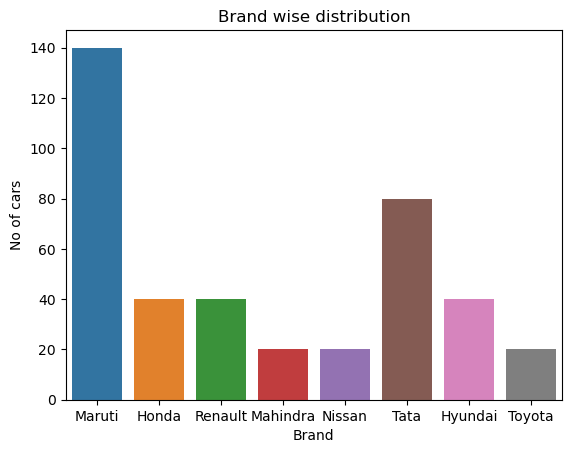

```python
sns.countplot(x=df["Brand"],palette='tab10',hue=df["Brand"])
plt.xlabel("Brand")
plt.ylabel("No of cars")
plt.title("Brand wise distribution")
```

### Insight:

- “The visualization highlights brand-wise supply distribution in the used-car market. Maruti dominates listings, indicating high resale activity, while brands like Toyota and Nissan show limited availability, suggesting potential scarcity-driven pricing.Easier for buyers to find Maruti cars at competitive prices”

### Type of fuel used mostly

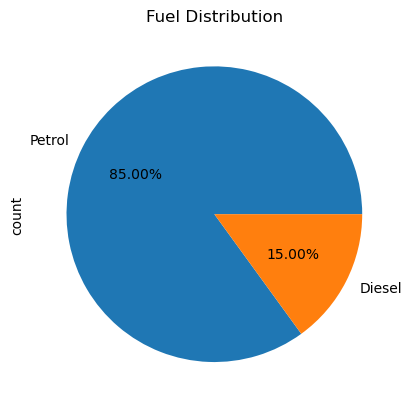

```python
df["Fuel"].value_counts().plot(kind="pie",autopct='%.2f%%')
plt.title("Fuel Distribution")
```

### Insight:

- “The fuel-type distribution shows that petrol cars dominate the used-car listings, accounting for 85% of the supply. Diesel cars form a smaller segment, indicating changing market preferences and the impact of emission regulations.Buyers have more options and better price negotiation in petrol cars.”

### Average Price by Car Brand

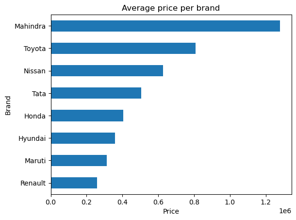

```python
df.groupby('Brand')['Price'].mean().sort_values().plot(kind='barh')
plt.xlabel("Price")
plt.ylabel("Brand")
plt.title("Average price per brand")
```

### Price Distribution (Overall)

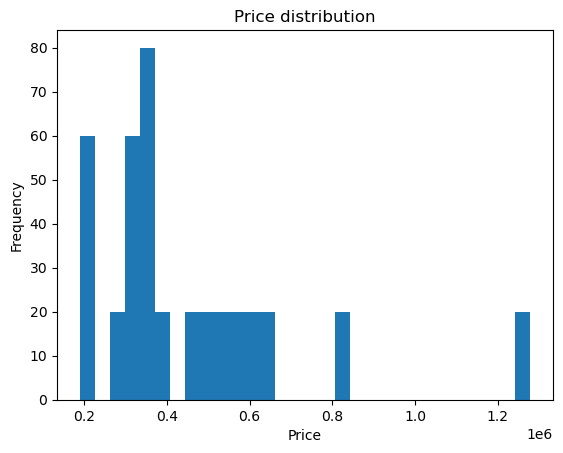

```python
df['Price'].plot(kind='hist', bins=30)
plt.xlabel("Price")
plt.ylabel("Frequency")
plt.title("Price distribution")
```

### Insight:

“The price distribution of used cars is positively skewed, with most listings concentrated in the ₹2–4 lakh range. A small number of high-priced vehicles create outliers, reinforcing the use of median price for accurate market analysis.Few cars priced above ₹8–12 lakhs. These are likely:Premium brands,Newer models,Low km driven vehicles”

### Price vs Km_Driven

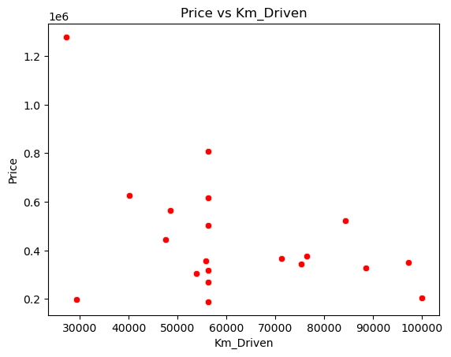

```python
sns.scatterplot(x=df["Km_Driven"],y=df["Price"],color='red')
plt.title("Price vs Km_Driven")
```

### Insight:

- “The scatter plot reveals a negative correlation between kilometers driven and resale price. While price generally decreases with higher usage,mileage levels highlights the importance of brand, model, and vehicle condition.As kilometers driven increase, price generally decreases.Clear evidence of car depreciation with usage”

### Transmission Type Distribution

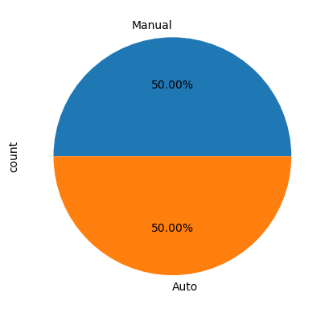

```python
df['Transmission_type'].value_counts().plot(kind='pie', autopct='%.2f%%')
```

### No of cars Manufactured per year

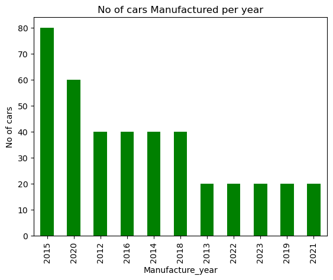

```python
df["Manufacture_year"].value_counts().plot(kind="bar",color="green")
plt.xlabel("Manufacture_year")
plt.ylabel("No of cars")
plt.title("No of cars Manufactured per year")
```

### Top 5 Most Listed Models

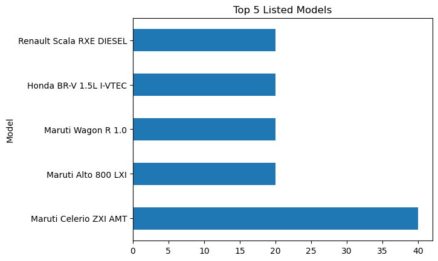

```python
df['Model'].value_counts().head(5).plot(kind='barh')
plt.title("Top 5 Listed Models")
```

### Outlier Detection (Boxplot)

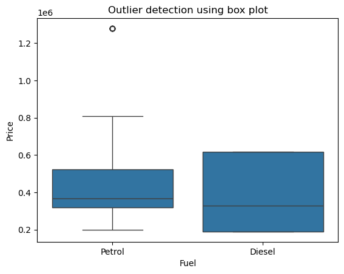

```python
sns.boxplot(x=df['Fuel'],y=df["Price"])
plt.title("Outlier detection using box plot")
```

### Insights:

“The boxplot reveals a right-skewed price distribution with a few high-price outliers. Since these extreme values can bias the mean, the median price is a more reliable metric for understanding the typical used-car price.One or more cars priced around ₹12–13 lakhs lie outside the upper whisker.These are statistical outliers”

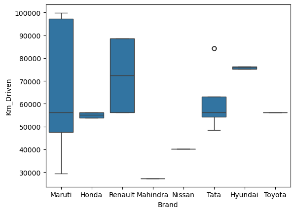

```python
sns.boxplot(x='Brand', y='Km_Driven', data=df)
```

### Brand vs Price

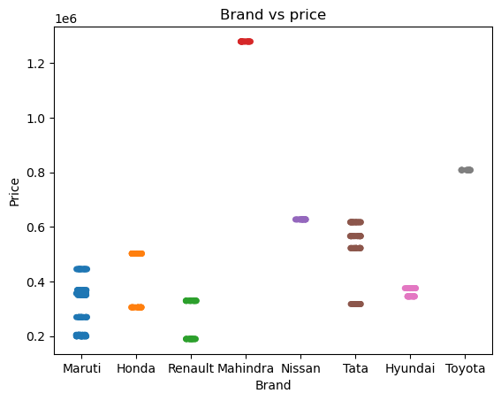

```python
sns.stripplot(x=df['Brand'],y=df['Price'],hue=df['Brand'])
plt.title("Brand vs price")
```

### Insight:

“The brand-wise price distribution shows clear market segmentation, with premium brands like Toyota and Mahindra commanding higher resale prices, while mass-market brands such as Maruti and Renault dominate the lower price segment.”

### Heat Map

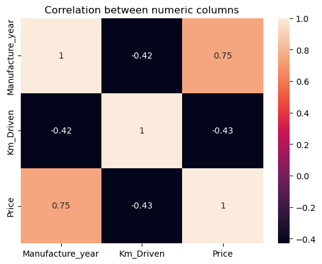

```python
sns.heatmap(df.corr(numeric_only=True),annot=True)
plt.title("Correlation between numeric columns")
```

### Insight:

“The correlation analysis shows that manufacture year has a strong positive relationship with price, while kilometers driven has a moderate negative impact. This indicates that car age plays a more critical role in used-car valuation.”

# Hypothesis Testing – Why?

Hypothesis testing helps us:

Validate assumptions with statistical evidence

Avoid decisions based only on visual trends

Provide confidence-backed insights

#### 1.Does fuel type affect car price?

🔹 Problem Statement

Do Petrol and Diesel cars have significantly different average prices?

🔹 Hypotheses

Null Hypothesis (H₀): Mean price of Petrol cars = Mean price of Diesel cars

Alternative Hypothesis (H₁): Mean price of Petrol cars ≠ Mean price of Diesel cars

🔹 Test Used

✅ Independent Two-Sample t-Test

```python
from scipy.stats import ttest_ind

petrol = df[df['Fuel'] == 'Petrol']['Price']
diesel = df[df['Fuel'] == 'Diesel']['Price']

t_stat, p_value = ttest_ind(petrol, diesel, equal_var=False)

print("T-statistic:", t_stat)
print("P-value:", p_value)
```

```
T-statistic: 3.060614839038217
P-value: 0.00279785007922424
```

### 🔹 Decision Rule

If p < 0.05 → Reject H₀

If p ≥ 0.05 → Fail to reject H₀

🔹 Business Insight

If rejected, fuel type significantly impacts pricing → pricing models should consider fuel type.

### 2. Is Km_Driven related to price?

🔹 Hypotheses

H₀: Km_Driven has no impact on car price

H₁: Km_Driven significantly impacts car price

🔹 Test Used

✅ Pearson Correlation Test

```python
from scipy.stats import pearsonr

corr, p_value = pearsonr(df['Km_Driven'], df['Price'])

print("Correlation:", corr)
print("P-value:", p_value)
```

```
Correlation: -0.43043842693936935
P-value: 1.795247314285117e-19
```

#### Decision Rule

If p < 0.05 → Reject H₀

If p ≥ 0.05 → Fail to reject H₀

#### Insight

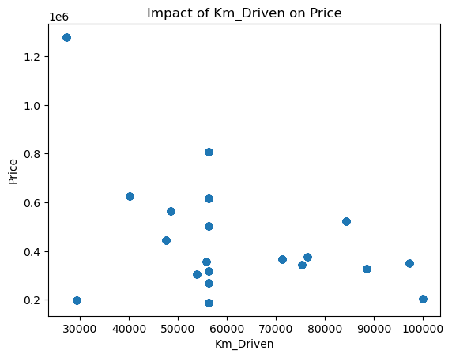

```python
import matplotlib.pyplot as plt

plt.scatter(df['Km_Driven'], df['Price'])
plt.xlabel('Km_Driven')
plt.ylabel('Price')
plt.title('Impact of Km_Driven on Price')
plt.show()
```